# Do smiles lead to more likes?

Athena Hadjixenofontos, PhD

## Load in the dataset

```r
emotions <- read.csv("../datasets/emotion-likes-dataset.csv", header = TRUE, stringsAsFactors = FALSE)
head(emotions)
```

|  | image.name | emotion | likes |
| --- | --- | --- | --- |
| 1 | face1.jpg | happiness | 50 |
| 2 | face2.jpg | happiness | 380 |
| 3 | face3.jpg | happiness | 221 |
| 4 | face8.jpg | happiness | 81 |
| 5 | face9.jpg | happiness | 199 |
| 6 | face12.jpg | happiness | 186 |

## Explore the dataset

### Birds-eye view: what do we have here?

```r
str(emotions)
```

```
'data.frame':   107 obs. of  3 variables:
 $ image.name: chr  "face1.jpg" "face2.jpg" "face3.jpg" "face8.jpg" ...
 $ emotion   : chr  "happiness" "happiness" "happiness" "happiness" ...
 $ likes     : int  50 380 221 81 199 186 247 211 399 227 ...
```

We see that for each of the images (indicated by their file name in the image.name variable), we have an emotion associated with it, and the number of likes that it got on social media.

Although we can’t yet tell anything about a possible relationship between likes and happiness, we now know how our variables are represented.

In this dataset, emotions are represented as categorical variables. What other options exist for representing emotions?

On the more technical side, emotions are stored as a character string, which in R is called the “character” data type, abbreviated as “chr”.

The number of likes is a continuous variable, stored as an integer, abbreviated as “int”.

You can use str() to find out the structure of any object that has any data type, not only of a data frame containing data that you’ve read in.

### Some terminology: data types

For the computer to know what to do when you ask it to e.g. return the sum two integers, it first needs to know that the two things that you’re giving it are integers. The various classifications that data can take are called data types. In R, there are 6 data types. The 4 most commonly used ones are: character, integer, logical, and numeric (also called “double”, and as opposed to the integer data type it can store numbers with decimals).

These four can be used to build more complicated data types. For example, individual letters characters come together to make a string of characters.

### The more information you get, the more questions arise

Okay, so now that you have a better idea of what’s what, let’s return to thinking about the emotions dataset. What are some of the questions that come up for you when you look at the output of str()?

Here are some of my questions: 1) How many different values does the emotion variable take? 2) (Related to Q1) How many photos do we have for each of the emotions? 3) (Related to Q1) Could this distribution of the various emotions be a problem when we try to answer the question that drives our analysis? 4) What is the maximum and what is the minimum number of likes that a photo has in this dataset? 5) (Related to Q4) What is the distribution of likes across all photos? 6) (Related to Q4) Does this distribution change if I only consider photos classified with the “happiness” emotion?

That’s a start - I’m sure that more questions (perhaps more meaningful and/or more specific questions) will arise as we’re answering these, so I’ll hold off on making the list much longer, for now.

You may also have questions about whether the emotion variable is acurrately encoding the emotion displayed in the photo. Do you trust the encoding? I hope you do have this question, and others along the same lines!

In order to answer those types of questions, we’d need an “objective” mapping of facial expressions to emotions. That information isn’t available in our dataset, so although the accuracy question is a legitimate one, we’ll put it and the others in its category aside for now, while we’re working with the information that we do have at hand.

### Descriptive statistics

(Introduce data types: chr, int and data frames) (Introduce variable types: categorical, continuous, binary/dichotomous, ordinal etc)

```r
table(emotions$emotion)
```

```
    anger  contempt happiness   neutral  surprise
        4         1        42        56         4
```

```r
max(emotions$likes)
```

```
[1] 416
```

```r
min(emotions$likes)
```

```
[1] 6
```

```r
mean(emotions$likes)
```

```
[1] 141.6449
```

```r
sd(emotions$likes)
```

```
[1] 90.75836
```

Cool! Which questions can we now answer (from above)?

For Q3, what if the value we were interested in was “anger” instead of “happiness”? Would we be able to continue our analysis? Why/why not?

### A picture is worth a thousand words: Descriptive graphs

Histograms are used to visualize the distributions of continuous variables.

Barplots are used to visualize the distributions of categorical variables.

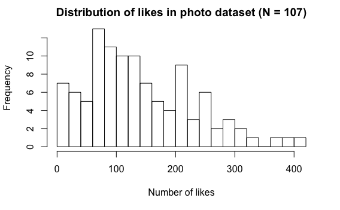

```r
# Histogram of number of likes
hist(emotions$likes, xlab = "Number of likes", main = "Distribution of likes in photo dataset (N = 107)", breaks = 20)
```

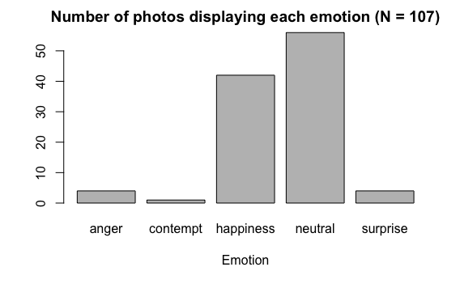

```r
# Barplot of the numbers of each emotion
freq_emotions <- table(emotions$emotion)  # Rerun the frequency table command, saving the output to a variable
barplot(freq_emotions, xlab = "Emotion", main = "Number of photos displaying each emotion (N = 107)")
```

Why did we need to feed the frequency table into the barplot() function rather than the emotions$emotion variable?

Notice that we’re using functions from a library called graphics, which is part of base R, hist() and barplot(). Base R is the core set that comes with the installation of R itself, rather than any other libraries. Pulling up the help for either of these two functions will show you which library they are a part of: hist {graphics}

Why am I even pointing this out? Because it has to do with the person who developed the functionality and the group that they were affiliated with. Software is created by people, like you and I, who are a part of the greater community of developers.

Extra: Can you use what you learned about making plots in ggplot2 to remake these same two plots using the function ggplot()?

### Let’s talk about relationships

Visualized by scatterplot (if both are continuous, can also calculate correlation) - why? or boxplot (if one is continuous and one is categorical) - why?

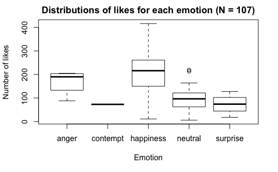

```r
boxplot(emotions$likes ~ emotions$emotion, xlab = "Emotion", ylab = "Number of likes", main = "Distributions of likes for each emotion (N = 107)")
```

What can you tell from this plot about the relationship of each emotion with number of likes?

How far can we extend inference at this point?

Is anything surprising?

Does this establish a causal relationship between smiling and getting lots of likes? Do we know for a fact that the smiles in these photos are what caused them to get this many likes, compared to the other emotions? Why/why not?

In addition to “hidden” variables driving this apparent association, one possible reason that could have given rise to it is chance. The bigger the difference, the less likely to have been caused by chance.

Causal relationships are notoriously difficult to establish. There are a set of criteria that need to be fulfilled, but most of the time studies do not have the resources or the correct experimental design to be able to establish causality.

### Quality Control

Can we remove the two outiers in the neutral photos? Why/why not?

Let’s eliminate all the data that we’re not interested in for this analysis, to end up with a **clean dataset**.

```r
clean <- emotions[emotions$emotion == "happiness" | emotions$emotion == "neutral",]
```

### Differences between groups: do happy faces get more likes?

Broad differences: are the means of how many likes a photo got different for each of the emotions?

We’ve seen the rough distribution in the box and whisker plot, which did well for giving us a sense of how many likes each group of pictures got, according to our dataset.

```r
happy <- emotions[emotions$emotion == "happiness", ]
neutral <- emotions[emotions$emotion == "neutral", ]
max(happy$likes, na.rm = TRUE)
```

```
[1] 416
```

```r
min(happy$likes, na.rm = TRUE)
```

```
[1] 11
```

```r
mean(happy$likes, na.rm = TRUE)
```

```
[1] 212.0714
```

```r
sd(happy$likes, na.rm = TRUE)
```

```
[1] 94.1857
```

```r
max(neutral$likes, na.rm = TRUE)
```

```
[1] 219
```

```r
min(neutral$likes, na.rm = TRUE)
```

```
[1] 6
```

```r
mean(neutral$likes, na.rm = TRUE)
```

```
[1] 93.01786
```

```r
sd(neutral$likes, na.rm = TRUE)
```

```
[1] 48.14315
```

We’re getting a little bit more detail about the differences between these two groups of photos. The variances are unequal - this becomes important with the type of test we will use to calculate the proability that we got this difference in number of likes between the happy and neutral groups by chance.

(Introduce functions? Repeated code is not good practice.)

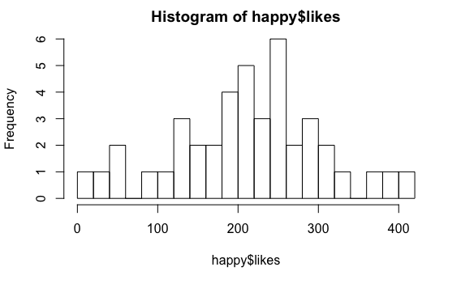

```r
hist(happy$likes, breaks = 20)
```

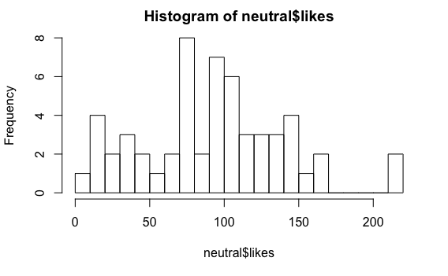

```r
hist(neutral$likes, breaks = 20)
```

```r
t.test(x = happy$likes, y = neutral$likes, alternative = "two.sided")
```

```
    Welch Two Sample t-test

data:  happy$likes and neutral$likes
t = 7.4907, df = 57.011, p-value = 4.833e-10
alternative hypothesis: true difference in means is not equal to 0
95 percent confidence interval:
  87.22763 150.87952
sample estimates:
mean of x mean of y
212.07143  93.01786
```

## Come up with other variables that may be important

### Which of these can you get information on?

Info associated with the file, info that you can infer by looking at the photo.

### Is the person in the photo in popular locations?

Geolocation may be one but the photos are stock photos, and that info is not part of their metadata. What else is part of their metadata? What would you do to take a look?

### Are the colors of the photo warm, happy colors?

How about average color? Do images with warmer colors and smiles get more likes than images with cooler colors and smiles? How would I find out?

### Is the person in the photo a celebrity?

```r
library(exifr)

# Go to the folder where the pictures are saved
setwd("../faces-photos/")

# Read in the picture metadata for all photos in the folder
photo_metadata <- exifr(".", recursive = TRUE)
```

Inside/outside

Average color is something that you can calculate based only on the image file.

## Add the variable that you chose to the dataset. Is there a relationship?

## How about conditional relationships? Are smiles only getting more likes if the colors of the picture are also warm?